# PISA Data Exploration

## Preliminary Wrangling

The initial Pisa dataset contains 485490 PISA assessment with 636 features (reading, math and science related), representing about 28 million 15-year-olds globally for year 2012.

```python
# import all packages and set plots to be embedded inline
import numpy as np
import pandas as pd
import matplotlib.pyplot as plt
import seaborn as sb

%matplotlib inline
```

Load the data set and its column name explanations

```python
Pisa=pd.read_csv("pisa2012.csv",encoding = "ISO-8859-1")
Pisa.head()
```

|  | Unnamed: 0 | CNT | SUBNATIO | STRATUM | OECD | NC | SCHOOLID | STIDSTD | ST01Q01 | ST02Q01 | ... | W_FSTR75 | W_FSTR76 | W_FSTR77 | W_FSTR78 | W_FSTR79 | W_FSTR80 | WVARSTRR | VAR_UNIT | SENWGT_STU | VER_STU |
| --- | --- | --- | --- | --- | --- | --- | --- | --- | --- | --- | --- | --- | --- | --- | --- | --- | --- | --- | --- | --- | --- |
| 0 | 1 | Albania | 80000 | ALB0006 | Non-OECD | Albania | 1 | 1 | 10 | 1.0 | ... | 13.7954 | 13.9235 | 13.1249 | 13.1249 | 4.3389 | 13.0829 | 19 | 1 | 0.2098 | 22NOV13 |
| 1 | 2 | Albania | 80000 | ALB0006 | Non-OECD | Albania | 1 | 2 | 10 | 1.0 | ... | 13.7954 | 13.9235 | 13.1249 | 13.1249 | 4.3389 | 13.0829 | 19 | 1 | 0.2098 | 22NOV13 |
| 2 | 3 | Albania | 80000 | ALB0006 | Non-OECD | Albania | 1 | 3 | 9 | 1.0 | ... | 12.7307 | 12.7307 | 12.7307 | 12.7307 | 4.2436 | 12.7307 | 19 | 1 | 0.1999 | 22NOV13 |
| 3 | 4 | Albania | 80000 | ALB0006 | Non-OECD | Albania | 1 | 4 | 9 | 1.0 | ... | 12.7307 | 12.7307 | 12.7307 | 12.7307 | 4.2436 | 12.7307 | 19 | 1 | 0.1999 | 22NOV13 |
| 4 | 5 | Albania | 80000 | ALB0006 | Non-OECD | Albania | 1 | 5 | 9 | 1.0 | ... | 12.7307 | 12.7307 | 12.7307 | 12.7307 | 4.2436 | 12.7307 | 19 | 1 | 0.1999 | 22NOV13 |

5 rows × 636 columns

```python
#Read in the column names explanation for original PISA data

Col_explanation=pd.read_csv("pisadict2012.csv",encoding = "ISO-8859-1")
Col_explanation.columns=["Ab","Feature"]
Col_explanation
```

|  | Ab | Feature |
| --- | --- | --- |
| 0 | CNT | Country code 3-character |
| 1 | SUBNATIO | Adjudicated sub-region code 7-digit code (3-di... |
| 2 | STRATUM | Stratum ID 7-character (cnt + region ID + orig... |
| 3 | OECD | OECD country |
| 4 | NC | National Centre 6-digit Code |
| 5 | SCHOOLID | School ID 7-digit (region ID + stratum ID + 3-... |
| 6 | STIDSTD | Student ID |
| 7 | ST01Q01 | International Grade |
| 8 | ST02Q01 | National Study Programme |
| 9 | ST03Q01 | Birth - Month |
| 10 | ST03Q02 | Birth -Year |
| 11 | ST04Q01 | Gender |
| 12 | ST05Q01 | Attend <ISCED 0> |
| 13 | ST06Q01 | Age at <ISCED 1> |
| 14 | ST07Q01 | Repeat - <ISCED 1> |
| 15 | ST07Q02 | Repeat - <ISCED 2> |
| 16 | ST07Q03 | Repeat - <ISCED 3> |
| 17 | ST08Q01 | Truancy - Late for School |
| 18 | ST09Q01 | Truancy - Skip whole school day |
| 19 | ST115Q01 | Truancy - Skip classes within school day |
| 20 | ST11Q01 | At Home - Mother |
| 21 | ST11Q02 | At Home - Father |
| 22 | ST11Q03 | At Home - Brothers |
| 23 | ST11Q04 | At Home - Sisters |
| 24 | ST11Q05 | At Home - Grandparents |
| 25 | ST11Q06 | At Home - Others |
| 26 | ST13Q01 | Mother<Highest Schooling> |
| 27 | ST14Q01 | Mother Qualifications - <ISCED level 6> |
| 28 | ST14Q02 | Mother Qualifications - <ISCED level 5A> |
| 29 | ST14Q03 | Mother Qualifications - <ISCED level 5B> |
| ... | ... | ... |
| 605 | W_FSTR55 | FINAL STUDENT REPLICATE BRR-FAY WEIGHT55 |
| 606 | W_FSTR56 | FINAL STUDENT REPLICATE BRR-FAY WEIGHT56 |
| 607 | W_FSTR57 | FINAL STUDENT REPLICATE BRR-FAY WEIGHT57 |
| 608 | W_FSTR58 | FINAL STUDENT REPLICATE BRR-FAY WEIGHT58 |
| 609 | W_FSTR59 | FINAL STUDENT REPLICATE BRR-FAY WEIGHT59 |
| 610 | W_FSTR60 | FINAL STUDENT REPLICATE BRR-FAY WEIGHT60 |
| 611 | W_FSTR61 | FINAL STUDENT REPLICATE BRR-FAY WEIGHT61 |
| 612 | W_FSTR62 | FINAL STUDENT REPLICATE BRR-FAY WEIGHT62 |
| 613 | W_FSTR63 | FINAL STUDENT REPLICATE BRR-FAY WEIGHT63 |
| 614 | W_FSTR64 | FINAL STUDENT REPLICATE BRR-FAY WEIGHT64 |
| 615 | W_FSTR65 | FINAL STUDENT REPLICATE BRR-FAY WEIGHT65 |
| 616 | W_FSTR66 | FINAL STUDENT REPLICATE BRR-FAY WEIGHT66 |
| 617 | W_FSTR67 | FINAL STUDENT REPLICATE BRR-FAY WEIGHT67 |
| 618 | W_FSTR68 | FINAL STUDENT REPLICATE BRR-FAY WEIGHT68 |
| 619 | W_FSTR69 | FINAL STUDENT REPLICATE BRR-FAY WEIGHT69 |
| 620 | W_FSTR70 | FINAL STUDENT REPLICATE BRR-FAY WEIGHT70 |
| 621 | W_FSTR71 | FINAL STUDENT REPLICATE BRR-FAY WEIGHT71 |
| 622 | W_FSTR72 | FINAL STUDENT REPLICATE BRR-FAY WEIGHT72 |
| 623 | W_FSTR73 | FINAL STUDENT REPLICATE BRR-FAY WEIGHT73 |
| 624 | W_FSTR74 | FINAL STUDENT REPLICATE BRR-FAY WEIGHT74 |
| 625 | W_FSTR75 | FINAL STUDENT REPLICATE BRR-FAY WEIGHT75 |
| 626 | W_FSTR76 | FINAL STUDENT REPLICATE BRR-FAY WEIGHT76 |
| 627 | W_FSTR77 | FINAL STUDENT REPLICATE BRR-FAY WEIGHT77 |
| 628 | W_FSTR78 | FINAL STUDENT REPLICATE BRR-FAY WEIGHT78 |
| 629 | W_FSTR79 | FINAL STUDENT REPLICATE BRR-FAY WEIGHT79 |
| 630 | W_FSTR80 | FINAL STUDENT REPLICATE BRR-FAY WEIGHT80 |
| 631 | WVARSTRR | RANDOMIZED FINAL VARIANCE STRATUM (1-80) |
| 632 | VAR_UNIT | RANDOMLY ASSIGNED VARIANCE UNIT |
| 633 | SENWGT_STU | Senate weight - sum of weight within the count... |
| 634 | VER_STU | Date of the database creation |

635 rows × 2 columns

```python
Pisa.shape
```

```
(485490, 636)
```

Take a close look at the original variables and choose a few of interest for further analysis. At the same time , store all the column explanations into a dictionary.

```python
# Take a close look at all the variables

Ab_dict=dict()
for i in Col_explanation.index:
    key=Col_explanation["Ab"][i]
    Ab_dict[key]=Col_explanation.Feature[i]
    print (i,Col_explanation["Ab"][i],Col_explanation.Feature[i])
```

```
0 CNT Country code 3-character
1 SUBNATIO Adjudicated sub-region code 7-digit code (3-digit country code + region ID + stratum ID)
2 STRATUM Stratum ID 7-character (cnt + region ID + original stratum ID)
3 OECD OECD country
4 NC National Centre 6-digit Code
5 SCHOOLID School ID 7-digit (region ID + stratum ID + 3-digit school ID)
6 STIDSTD Student ID
7 ST01Q01 International Grade
8 ST02Q01 National Study Programme
9 ST03Q01 Birth - Month
10 ST03Q02 Birth -Year
11 ST04Q01 Gender
12 ST05Q01 Attend <ISCED 0>
13 ST06Q01 Age at <ISCED 1>
14 ST07Q01 Repeat - <ISCED 1>
```

[output cut: 620 more lines]

```python
#Choose a few variables of interest for following analysis
Variable_list=["NC","OECD","ST04Q01","GRADE","ESCS","MMINS","OUTHOURS","ANCINTMAT","ANCMATWKETH","ANCCOGACT","ANCSTUDREL","ANCMTSUP","ANCATSCHL","ANCATTLNACT","ANCBELONG"]

Pisa_result=Pisa.loc[:,Variable_list]

# store the target Pisa fragment in a CSV file
Pisa_result.to_csv("Pisa_result.csv",index=False)
```

```python
#Show all the chosen variables

for v in Variable_list:
    print (v,"       "+Ab_dict[v])
```

```
NC        National Centre 6-digit Code
OECD        OECD country
ST04Q01        Gender
GRADE        Grade compared to modal grade in country
ESCS        Index of economic, social and cultural status
MMINS        Learning time (minutes per week)- <Mathematics>
OUTHOURS        Out-of-School Study Time
ANCINTMAT        Mathematics Interest (Anchored)
ANCMATWKETH        Mathematics Work Ethic (Anchored)
ANCCOGACT        Cognitive Activation in Mathematics Lessons (Anchored)
ANCSTUDREL        Teacher Student Relations (Anchored)
ANCMTSUP        Mathematics Teacher's Support (Anchored)
ANCATSCHL        Attitude towards School: Learning Outcomes (Anchored)
ANCATTLNACT        Attitude towards School: Learning Activities (Anchored)
ANCBELONG        Sense of Belonging to School (Anchored)
```

I also need to rename some columns names to convey clearer message.

```python
Pisa_result.rename(columns={"NC":"COUNTRY","ST04Q01":"GENDER"},inplace=True)
```

```python
Pisa_result.sample(20)
```

|  | COUNTRY | OECD | GENDER | GRADE | ESCS | MMINS | OUTHOURS | ANCINTMAT | ANCMATWKETH | ANCCOGACT | ANCSTUDREL | ANCMTSUP | ANCATSCHL | ANCATTLNACT | ANCBELONG |
| --- | --- | --- | --- | --- | --- | --- | --- | --- | --- | --- | --- | --- | --- | --- | --- |
| 383068 | Poland | OECD | Female | 0.0 | -1.02 | 225.0 | 16.0 | NaN | NaN | 0.0766 | -0.1673 | -0.2352 | 0.0526 | -0.6779 | 0.2570 |
| 305442 | Luxembourg | OECD | Male | 1.0 | 1.00 | 270.0 | 3.0 | NaN | NaN | NaN | NaN | NaN | NaN | NaN | NaN |
| 279264 | Japan | OECD | Female | 0.0 | -0.64 | 250.0 | 4.0 | NaN | NaN | NaN | NaN | NaN | NaN | NaN | NaN |
| 8325 | United Arab Emirates | Non-OECD | Female | 0.0 | 0.73 | 350.0 | 30.0 | NaN | NaN | 0.0766 | 0.3536 | 0.4052 | 0.1565 | 0.4908 | 0.6458 |
| 37887 | Austria | OECD | Male | -1.0 | -0.73 | 100.0 | 8.0 | NaN | NaN | 0.4940 | 0.2492 | 0.1541 | 0.2818 | 0.0309 | 0.6458 |
| 301265 | Luxembourg | OECD | Female | 1.0 | 1.69 | NaN | NaN | -1.2195 | 0.6599 | 0.4142 | -0.5138 | -0.2352 | -0.3395 | 0.0923 | 0.5513 |
| 230252 | Ireland | OECD | Female | 1.0 | 0.35 | NaN | NaN | 0.0486 | -0.3339 | -0.0561 | -0.3870 | -0.4365 | -0.3395 | -0.5937 | -0.4549 |
| 422606 | Russian Federation | Non-OECD | Male | 0.0 | 0.47 | 120.0 | 10.0 | NaN | NaN | -1.0353 | -2.6658 | -2.0354 | -2.7779 | -2.6090 | -3.3731 |
| 247395 | Italy | OECD | Male | 0.0 | -0.36 | NaN | 10.0 | NaN | NaN | -0.1278 | -0.4474 | -0.5121 | -0.5623 | -0.8146 | -0.5259 |
| 13776 | United Arab Emirates | Non-OECD | Female | 0.0 | 1.08 | 200.0 | 18.0 | NaN | NaN | 0.5827 | -0.8079 | 2.6379 | 0.4410 | 2.0009 | 0.1992 |
| 371131 | New Zealand | OECD | Male | 0.0 | 0.45 | NaN | NaN | 0.4816 | 0.3492 | 0.6314 | 0.3536 | 0.4052 | 0.1565 | 0.1807 | 0.3895 |
| 222192 | Indonesia | Non-OECD | Male | 0.0 | 0.56 | 120.0 | 48.0 | NaN | NaN | -0.8636 | -1.0029 | -0.8529 | -1.0340 | -1.5921 | -1.0822 |
| 48726 | Belgium | OECD | Female | 0.0 | 0.78 | 250.0 | 15.0 | NaN | NaN | NaN | NaN | NaN | NaN | NaN | NaN |
| 485060 | Viet Nam | Non-OECD | Female | 0.0 | -1.93 | 225.0 | 41.0 | NaN | NaN | 0.5827 | 0.1593 | 0.2669 | 0.0526 | -0.3846 | 0.0964 |
| 334321 | Mexico | OECD | Female | 0.0 | -2.55 | 250.0 | 16.0 | NaN | NaN | NaN | NaN | NaN | NaN | NaN | NaN |
| 63715 | Brazil | Non-OECD | Female | 0.0 | -1.97 | 135.0 | 18.0 | NaN | NaN | NaN | NaN | NaN | NaN | NaN | NaN |
| 417858 | Russian Federation | Non-OECD | Male | 0.0 | 0.61 | 225.0 | 25.0 | NaN | NaN | NaN | NaN | NaN | NaN | NaN | NaN |
| 34985 | Australia | OECD | Male | 0.0 | 0.71 | NaN | NaN | NaN | NaN | NaN | NaN | NaN | NaN | NaN | NaN |
| 409844 | United States of America | Non-OECD | Male | 0.0 | 1.14 | 250.0 | 9.0 | NaN | NaN | 0.8023 | 1.0099 | 0.8270 | 0.2818 | 0.4908 | 0.3895 |
| 160137 | Spain | OECD | Female | -2.0 | -1.45 | NaN | NaN | -1.6958 | -1.4853 | -0.5365 | -1.3056 | -2.0354 | -0.4846 | -0.4928 | -0.1489 |

Select the data of interest with 15 associated variables and store them in another data frame called Pisa_result.

```python
Pisa_result.info()
```

```
<class 'pandas.core.frame.DataFrame'>
RangeIndex: 485490 entries, 0 to 485489
Data columns (total 15 columns):
COUNTRY        485490 non-null object
OECD           485490 non-null object
GENDER         485490 non-null object
GRADE          484617 non-null float64
ESCS           473648 non-null float64
MMINS          283303 non-null float64
OUTHOURS       308799 non-null float64
ANCINTMAT      155280 non-null float64
ANCMATWKETH    153879 non-null float64
ANCCOGACT      308150 non-null float64
ANCSTUDREL     308058 non-null float64
ANCMTSUP       308631 non-null float64
ANCATSCHL      306835 non-null float64
ANCATTLNACT    306487 non-null float64
ANCBELONG      307640 non-null float64
dtypes: float64(12), object(3)
memory usage: 55.6+ MB
```

```python
Pisa_result.describe()
```

|  | GRADE | ESCS | MMINS | OUTHOURS | ANCINTMAT | ANCMATWKETH | ANCCOGACT | ANCSTUDREL | ANCMTSUP | ANCATSCHL | ANCATTLNACT | ANCBELONG |
| --- | --- | --- | --- | --- | --- | --- | --- | --- | --- | --- | --- | --- |
| count | 484617.000000 | 473648.000000 | 283303.000000 | 308799.000000 | 155280.000000 | 153879.000000 | 308150.000000 | 308058.000000 | 308631.000000 | 306835.000000 | 306487.000000 | 307640.000000 |
| mean | -0.162964 | -0.265546 | 226.007056 | 11.104100 | 0.078194 | 0.010586 | -0.008190 | -0.009193 | 0.029555 | -0.033189 | -0.045223 | -0.082717 |
| std | 0.655558 | 1.131791 | 97.448421 | 10.476669 | 1.008570 | 1.002834 | 0.994403 | 1.007970 | 1.018915 | 1.005530 | 1.020514 | 1.005093 |
| min | -3.000000 | -5.950000 | 0.000000 | 0.000000 | -1.695800 | -2.743000 | -3.067400 | -2.665800 | -2.749200 | -2.777900 | -2.609000 | -3.373100 |
| 25% | 0.000000 | -1.000000 | 180.000000 | 4.000000 | -0.350200 | -0.255800 | -0.248900 | -0.387000 | -0.367100 | -0.411000 | -0.593700 | -0.420600 |
| 50% | 0.000000 | -0.190000 | 220.000000 | 8.000000 | 0.114700 | 0.144900 | 0.173100 | 0.080900 | 0.154100 | 0.052600 | 0.030900 | 0.050100 |
| 75% | 0.000000 | 0.610000 | 250.000000 | 14.000000 | 0.792500 | 0.504600 | 0.513300 | 0.475900 | 0.583100 | 0.441000 | 0.490800 | 0.466200 |
| max | 3.000000 | 3.690000 | 3000.000000 | 180.000000 | 2.998400 | 2.970700 | 3.460300 | 2.821100 | 2.637900 | 3.042300 | 2.000900 | 3.255400 |

### What is the structure of your dataset?

There are 485490 pisa records in the dataset Pisa_result with 15 features (column names explained as below), extracted from PISA 2012 assessment of reading, math and science representing about 28million 15-year-olds globally.

COUNTRY National Centre 6-digit Codenn

OECD Whether belongs to the OECD organisition

GENDER Gender

GRADE Grade compared to modal grade in country

ESCS Index of economic, social and cultural status

MMINS Learning time (minutes per week)-

OUTHOURS Out-of-School Study Time (hours per week)

ANCINTMAT Mathematics Interest (Anchored)

ANCMATWKETH Mathematics Work Ethic (Anchored)

ANCCOGACT Cognitive Activation in Mathematics Lessons (Anchored)

ANCSTUDREL Teacher Student Relations (Anchored)

ANCMTSUP Mathematics Teacher's Support (Anchored)

ANCATSCHL Attitude towards School: Learning Outcomes (Anchored)

ANCATTLNACT Attitude towards School: Learning Activities (Anchored)

ANCBELONG Sense of Belonging to School (Anchored)

Most variables are numeric in nature, except the variables COUNTRY, OECD, and GENDER, which can be viewed as categorical variables with no order.

### What is/are the main feature(s) of interest in your dataset?

I am mostly interested in figuring out what features are closest related to students sense of belonging to school in this dataset.Is there any gender or economic, social bias? Also, what can best prompt students to study more, expecially the math subject?

### What features in the dataset do you think will help support your investigation into your feature(s) of interest?

I expect students' attitude towards school learning, teacher and student relationship will have some effect on the students sense of belonging to school, which can strongly motivate student to spend more time studying.

I also expect math related teaching strategie will have some impact on students' math study time.

## Univariate Exploration

I'll start by looking at the distribution of students' sense of belonging to school.

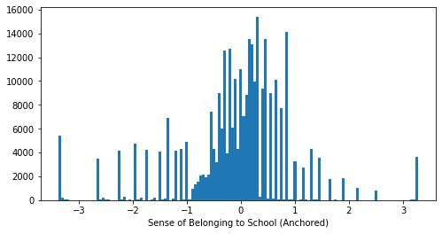

```python
fig = plt.figure(figsize=[8,4])
plt.hist(data=Pisa_result,x="ANCBELONG",bins=np.arange(min(Pisa_result["ANCBELONG"]), max(Pisa_result["ANCBELONG"])+0.05, 0.05))
plt.xlabel('{}'.format(Ab_dict["ANCBELONG"]));
```

This ANCBELONG is discrete numerical variable. The distribution looks like an unimodal centered around 0.2, with more data points falling into the range of -1 to 1.Notice: there are data spikes beyound both value -3 and 3, indicating that students' sense of belonging to school can be quite polarized.

I'll also start by investigating three categorical facors

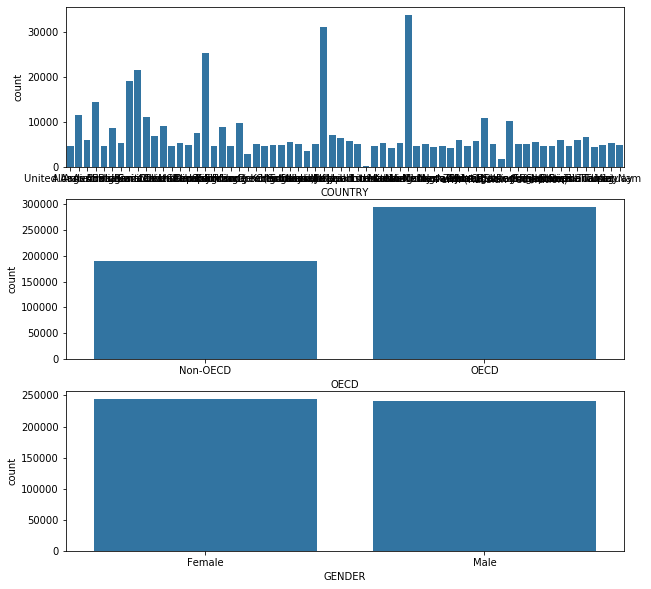

```python
# Investigate three categorical facors
fig, ax = plt.subplots(nrows=3, figsize = [10,10])

default_color = sb.color_palette()[0]
sb.countplot(data = Pisa_result, x = 'COUNTRY', color = default_color, ax = ax[0])
sb.countplot(data = Pisa_result, x = 'OECD', color = default_color, ax = ax[1])
sb.countplot(data = Pisa_result, x = 'GENDER', color = default_color, ax = ax[2])

plt.show()
```

```python
Pisa_result.COUNTRY.nunique()
```

```
66
```

```python
# Which coutries have the most records
Pisa_result.COUNTRY.value_counts().head(5)
```

```
Mexico     33806
Italy      31073
Spain      25313
Canada     21544
Brazil     19204
Name: COUNTRY, dtype: int64
```

```python
# Which coutries have the least records
Pisa_result.COUNTRY.value_counts().tail(5)
```

```
New Zealand                  4291
Iceland                      3508
United Kingdom (Scotland)    2945
Perm (Russian Federation)    1761
Liechtenstein                 293
Name: COUNTRY, dtype: int64
```

There are records from 66 countries in this data set, with distinctly varying numbers.More participants are from OECD (short for The Organisation for Economic Co-operation and Development) country, around 1.5 times of their Non-OECD counterparts. The distribution between Gender is quite balanced, roughly the same amount of female and male participants.

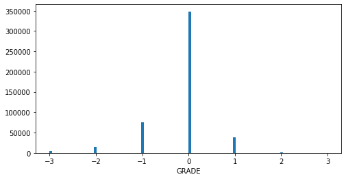

```python
# I will then look at the distribution of grade, which is compared to modal grade in specific country

fig = plt.figure(figsize=[8,4])
plt.hist(data=Pisa_result,x="GRADE",bins=100)
plt.xlabel("GRADE");
```

```python
Pisa_result.GRADE.value_counts()
```

```
 0.0    348298
-1.0     76159
 1.0     39179
-2.0     15528
-3.0      4370
 2.0      1078
 3.0         5
Name: GRADE, dtype: int64
```

Grade is discrete numeric variable.The majority value of 0 means most students in this data set are attending the same grade with their peers. The small portion of negative value means some of them lag behind in terms of attending classes. A tiny number of students are attending classes one grade higher, while very little of them are 2 or 3 grades ahead.

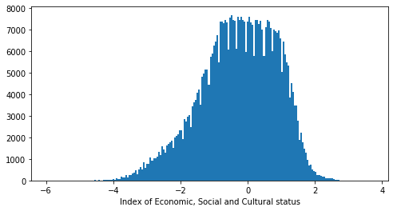

```python
#Move on to investigate the distribution of Economic, Social and Cultural status factor

fig = plt.figure(figsize=[8,4])
plt.hist(data=Pisa_result,x="ESCS",bins=200)
plt.xlabel("Index of Economic, Social and Cultural status");
```

The ESCS distribution is skewed left and is unimodal centered around 0, which means there are more participants in relative low ESCS status.

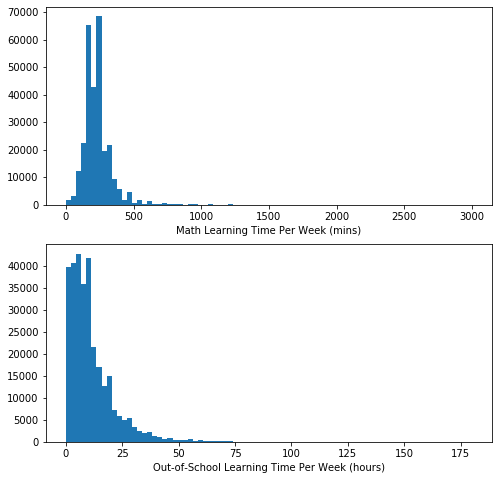

```python
# Look at the important learning time variables

fig, ax = plt.subplots(nrows=2, figsize = [8,8])

ax[0].hist(data=Pisa_result,x="MMINS",bins=80);
ax[0].set_xlabel('{} (mins)'.format("Math Learning Time Per Week"));

ax[1].hist(data=Pisa_result,x="OUTHOURS",bins=80);
ax[1].set_xlabel('{} (hours)'.format("Out-of-School Learning Time Per Week"));
```

On these initial math learning time and out-of-school learning plots, most of the data is set to the far left of their axes, suggesting some outliers on the right.We can also notice this on above description table.It's worth taking a bit of time to identify these outliers and see if they need to be filtered out of the data.

```python
# Take a look at all the learning time outliers
high_outliers = ((Pisa_result["MMINS"] > 1500) | (Pisa_result["OUTHOURS"] > 60))
Outliers_df=Pisa_result.loc[high_outliers,:]
Outliers_df
```

|  | COUNTRY | OECD | GENDER | GRADE | ESCS | MMINS | OUTHOURS | ANCINTMAT | ANCMATWKETH | ANCCOGACT | ANCSTUDREL | ANCMTSUP | ANCATSCHL | ANCATTLNACT | ANCBELONG |
| --- | --- | --- | --- | --- | --- | --- | --- | --- | --- | --- | --- | --- | --- | --- | --- |
| 2797 | Albania | Non-OECD | Male | 0.0 | NaN | 225.0 | 65.0 | NaN | NaN | -1.8184 | -1.6365 | -1.5787 | -1.3226 | -1.8911 | -1.9646 |
| 4295 | Albania | Non-OECD | Male | -1.0 | NaN | 180.0 | 70.0 | NaN | NaN | NaN | NaN | NaN | NaN | NaN | NaN |
| 4841 | United Arab Emirates | Non-OECD | Male | 0.0 | 0.82 | 150.0 | 85.0 | NaN | NaN | 0.2055 | -0.1113 | -0.1687 | -0.1954 | -0.5937 | -0.2191 |
| 4886 | United Arab Emirates | Non-OECD | Female | 0.0 | -0.46 | NaN | 62.0 | NaN | NaN | NaN | NaN | NaN | NaN | NaN | NaN |
| 4982 | United Arab Emirates | Non-OECD | Female | 0.0 | -2.03 | 270.0 | 124.0 | NaN | NaN | -0.3452 | -0.1113 | 0.5831 | 0.4410 | 0.1807 | -0.5259 |
| 5302 | United Arab Emirates | Non-OECD | Male | -2.0 | 0.58 | 330.0 | 71.0 | NaN | NaN | -1.5051 | -1.3056 | -1.5787 | -1.3226 | -1.2391 | -1.3424 |
| 5304 | United Arab Emirates | Non-OECD | Male | -1.0 | 0.06 | 450.0 | 84.0 | NaN | NaN | NaN | NaN | NaN | NaN | NaN | NaN |
| 5313 | United Arab Emirates | Non-OECD | Female | -1.0 | -1.67 | 270.0 | 84.0 | NaN | NaN | 0.2717 | 1.0099 | 0.0589 | 1.2799 | 1.0025 | 0.6458 |
| 5357 | United Arab Emirates | Non-OECD | Female | 0.0 | 0.31 | NaN | 70.0 | NaN | NaN | 0.5370 | 0.3536 | 0.5831 | 0.2818 | 0.4908 | 0.0501 |
| 5408 | United Arab Emirates | Non-OECD | Female | 1.0 | 0.08 | 270.0 | 100.0 | NaN | NaN | NaN | NaN | NaN | NaN | NaN | NaN |
| 5448 | United Arab Emirates | Non-OECD | Male | 0.0 | 0.51 | NaN | 144.0 | NaN | NaN | NaN | NaN | NaN | NaN | NaN | NaN |
| 5485 | United Arab Emirates | Non-OECD | Male | 0.0 | 1.44 | 560.0 | 63.0 | NaN | NaN | NaN | NaN | NaN | NaN | NaN | NaN |
| 5610 | United Arab Emirates | Non-OECD | Male | -3.0 | 0.08 | 315.0 | 81.0 | NaN | NaN | -0.0561 | -0.2757 | -0.8529 | 0.0526 | 0.4908 | -1.1975 |
| 5634 | United Arab Emirates | Non-OECD | Male | 0.0 | 1.04 | 315.0 | 70.0 | NaN | NaN | NaN | NaN | NaN | NaN | NaN | NaN |
| 5733 | United Arab Emirates | Non-OECD | Female | -1.0 | -0.60 | 225.0 | 118.0 | NaN | NaN | NaN | NaN | NaN | NaN | NaN | NaN |
| 5767 | United Arab Emirates | Non-OECD | Female | 0.0 | -0.93 | 270.0 | 67.0 | NaN | NaN | NaN | NaN | NaN | NaN | NaN | NaN |
| 5966 | United Arab Emirates | Non-OECD | Female | 0.0 | 0.50 | 960.0 | 63.0 | NaN | NaN | NaN | NaN | NaN | NaN | NaN | NaN |
| 6108 | United Arab Emirates | Non-OECD | Female | 0.0 | 1.26 | 200.0 | 70.0 | NaN | NaN | 0.0766 | 0.0111 | 0.1541 | -0.4846 | 0.4908 | -0.4206 |
| 6336 | United Arab Emirates | Non-OECD | Male | 1.0 | 1.05 | 240.0 | 62.0 | NaN | NaN | NaN | NaN | NaN | NaN | NaN | NaN |
| 6367 | United Arab Emirates | Non-OECD | Male | 1.0 | 0.05 | 360.0 | 65.0 | NaN | NaN | NaN | NaN | NaN | NaN | NaN | NaN |
| 6733 | United Arab Emirates | Non-OECD | Male | -2.0 | 0.59 | 240.0 | 68.0 | NaN | NaN | -0.0219 | -0.8079 | -0.8529 | -1.3226 | -1.2391 | -1.3424 |
| 6757 | United Arab Emirates | Non-OECD | Female | -1.0 | 1.81 | 225.0 | 72.0 | NaN | NaN | NaN | NaN | NaN | NaN | NaN | NaN |
| 6837 | United Arab Emirates | Non-OECD | Female | 0.0 | -0.28 | 225.0 | 99.0 | NaN | NaN | 0.2384 | -0.1113 | 0.4052 | 1.2799 | 1.0025 | 3.2554 |
| 6955 | United Arab Emirates | Non-OECD | Female | 0.0 | 0.78 | 180.0 | 84.0 | NaN | NaN | -3.0674 | -0.8079 | -0.8529 | -1.3226 | -1.2391 | -1.3424 |
| 7056 | United Arab Emirates | Non-OECD | Female | 0.0 | 0.73 | NaN | 130.0 | NaN | NaN | NaN | NaN | NaN | NaN | NaN | NaN |
| 7513 | United Arab Emirates | Non-OECD | Female | 2.0 | 1.04 | 320.0 | 70.0 | NaN | NaN | NaN | NaN | NaN | NaN | NaN | NaN |
| 7671 | United Arab Emirates | Non-OECD | Male | 2.0 | 0.30 | NaN | 67.0 | NaN | NaN | NaN | NaN | NaN | NaN | NaN | NaN |
| 7676 | United Arab Emirates | Non-OECD | Male | 2.0 | 0.83 | NaN | 66.0 | NaN | NaN | NaN | NaN | NaN | NaN | NaN | NaN |
| 7764 | United Arab Emirates | Non-OECD | Male | 1.0 | -0.59 | 210.0 | 61.0 | NaN | NaN | NaN | NaN | NaN | NaN | NaN | NaN |
| 7801 | United Arab Emirates | Non-OECD | Female | -1.0 | -0.82 | 250.0 | 83.0 | NaN | NaN | NaN | NaN | NaN | NaN | NaN | NaN |
| ... | ... | ... | ... | ... | ... | ... | ... | ... | ... | ... | ... | ... | ... | ... | ... |
| 481911 | Viet Nam | Non-OECD | Female | 0.0 | -1.56 | 322.0 | 65.0 | NaN | NaN | 0.3058 | -0.1113 | 0.1541 | 0.1565 | 0.4908 | -0.2868 |
| 482203 | Viet Nam | Non-OECD | Female | 0.0 | -2.19 | 180.0 | 63.0 | NaN | NaN | 0.0766 | -0.1673 | -0.0243 | 0.4410 | -0.1839 | 0.0501 |
| 482218 | Viet Nam | Non-OECD | Male | 0.0 | -1.13 | 180.0 | 62.0 | NaN | NaN | NaN | NaN | NaN | NaN | NaN | NaN |
| 482539 | Viet Nam | Non-OECD | Female | 0.0 | -1.22 | 135.0 | 66.0 | NaN | NaN | NaN | NaN | NaN | NaN | NaN | NaN |
| 482620 | Viet Nam | Non-OECD | Male | 0.0 | -1.36 | 225.0 | 64.0 | NaN | NaN | NaN | NaN | NaN | NaN | NaN | NaN |
| 482621 | Viet Nam | Non-OECD | Female | 0.0 | -1.43 | 225.0 | 64.0 | NaN | NaN | NaN | NaN | NaN | NaN | NaN | NaN |
| 482644 | Viet Nam | Non-OECD | Female | 0.0 | -2.31 | 225.0 | 69.0 | NaN | NaN | 0.2717 | 1.0099 | 0.8270 | 0.9305 | 0.4908 | 0.0064 |
| 482656 | Viet Nam | Non-OECD | Male | 0.0 | -0.47 | NaN | 61.0 | NaN | NaN | 0.4940 | 1.0099 | 0.8270 | 0.4410 | -0.0831 | 0.2570 |
| 482680 | Viet Nam | Non-OECD | Male | 0.0 | -0.95 | 270.0 | 62.0 | NaN | NaN | NaN | NaN | NaN | NaN | NaN | NaN |
| 482681 | Viet Nam | Non-OECD | Male | 0.0 | -0.08 | 270.0 | 69.0 | NaN | NaN | 0.6838 | 1.0099 | 1.5224 | 2.1880 | 0.1807 | 0.6458 |
| 482869 | Viet Nam | Non-OECD | Male | 0.0 | -2.63 | 180.0 | 62.0 | NaN | NaN | NaN | NaN | NaN | NaN | NaN | NaN |
| 483033 | Viet Nam | Non-OECD | Male | 0.0 | -1.96 | 225.0 | 71.0 | NaN | NaN | 0.1731 | 0.1593 | 0.4052 | 0.4410 | -0.3846 | -0.0744 |
| 483251 | Viet Nam | Non-OECD | Female | -1.0 | -3.11 | 180.0 | 84.0 | NaN | NaN | NaN | NaN | NaN | NaN | NaN | NaN |
| 483253 | Viet Nam | Non-OECD | Female | -1.0 | -2.03 | 180.0 | 63.0 | NaN | NaN | NaN | NaN | NaN | NaN | NaN | NaN |
| 483263 | Viet Nam | Non-OECD | Female | -1.0 | -3.29 | 180.0 | 63.0 | NaN | NaN | -0.3452 | -1.0029 | -0.1687 | 0.9305 | -0.9424 | -0.3202 |
| 483265 | Viet Nam | Non-OECD | Female | -1.0 | -1.72 | 180.0 | 109.0 | NaN | NaN | NaN | NaN | NaN | NaN | NaN | NaN |
| 483639 | Viet Nam | Non-OECD | Female | 0.0 | -0.75 | NaN | 65.0 | NaN | NaN | NaN | NaN | NaN | NaN | NaN | NaN |
| 483736 | Viet Nam | Non-OECD | Female | 0.0 | -2.10 | 180.0 | 66.0 | NaN | NaN | NaN | NaN | NaN | NaN | NaN | NaN |
| 483922 | Viet Nam | Non-OECD | Female | 0.0 | -0.95 | 180.0 | 70.0 | NaN | NaN | NaN | NaN | NaN | NaN | NaN | NaN |
| 484047 | Viet Nam | Non-OECD | Female | 0.0 | -1.75 | 180.0 | 96.0 | NaN | NaN | 0.2055 | -0.1673 | -0.0243 | 0.4410 | -0.6779 | -0.2868 |
| 484084 | Viet Nam | Non-OECD | Male | 0.0 | -1.84 | 180.0 | 70.0 | NaN | NaN | NaN | NaN | NaN | NaN | NaN | NaN |
| 484258 | Viet Nam | Non-OECD | Male | 0.0 | -0.49 | 225.0 | 84.0 | NaN | NaN | NaN | NaN | NaN | NaN | NaN | NaN |
| 484307 | Viet Nam | Non-OECD | Female | 0.0 | -1.59 | NaN | 69.0 | NaN | NaN | -0.1278 | -0.3303 | 0.0589 | -0.1954 | -0.2820 | -0.2868 |
| 484424 | Viet Nam | Non-OECD | Female | -2.0 | -0.72 | 180.0 | 79.0 | NaN | NaN | NaN | NaN | NaN | NaN | NaN | NaN |
| 484480 | Viet Nam | Non-OECD | Male | 0.0 | -2.53 | 180.0 | 68.0 | NaN | NaN | -0.6230 | -0.3303 | -0.3007 | -0.1954 | -0.7495 | -0.4549 |
| 484504 | Viet Nam | Non-OECD | Male | 0.0 | -2.46 | 180.0 | 70.0 | NaN | NaN | NaN | NaN | NaN | NaN | NaN | NaN |
| 484698 | Viet Nam | Non-OECD | Female | 0.0 | -1.16 | NaN | 84.0 | NaN | NaN | 0.0766 | -0.1113 | -0.1687 | -0.1954 | -0.5937 | -0.2191 |
| 485206 | Viet Nam | Non-OECD | Female | 0.0 | -0.78 | 180.0 | 65.0 | NaN | NaN | -0.0561 | 0.0809 | 0.4052 | 0.0526 | -0.2820 | -0.2633 |
| 485325 | Viet Nam | Non-OECD | Male | -1.0 | -1.69 | 180.0 | 70.0 | NaN | NaN | NaN | NaN | NaN | NaN | NaN | NaN |
| 485435 | Viet Nam | Non-OECD | Male | 0.0 | -1.32 | 180.0 | 65.0 | NaN | NaN | -0.1278 | -0.3870 | -0.3007 | -0.3395 | -0.8146 | -0.4206 |

1390 rows × 15 columns

```python
Outliers_df.COUNTRY.nunique(),Outliers_df.shape[0]
```

```
(60, 1390)
```

```python
Pisa_result=Pisa_result.loc[-high_outliers,:]
```

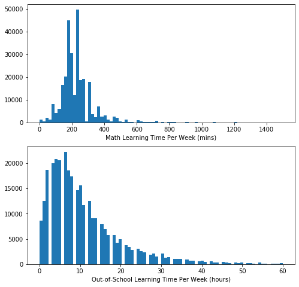

```python
# Look at the distribution again after removing those outliers

fig, ax = plt.subplots(nrows=2, figsize = [8,8])

ax[0].hist(data=Pisa_result,x="MMINS",bins=80);
ax[0].set_xlabel('{} (mins)'.format("Math Learning Time Per Week"));

ax[1].hist(data=Pisa_result,x="OUTHOURS",bins=80);
ax[1].set_xlabel('{} (hours)'.format("Out-of-School Learning Time Per Week"));
```

After removing the high-outliers, both study time distributions look like slightly right skewed unimodals.

I will then investigate math related and students attitute associated factors.

```
ANCINTMAT Mathematics Interest (Anchored)
ANCMATWKETH Mathematics Work Ethic (Anchored)
ANCCOGACT Cognitive Activation in Mathematics Lessons (Anchored)
ANCSTUDREL Teacher Student Relations (Anchored)
ANCMTSUP Mathematics Teacher's Support (Anchored)
```

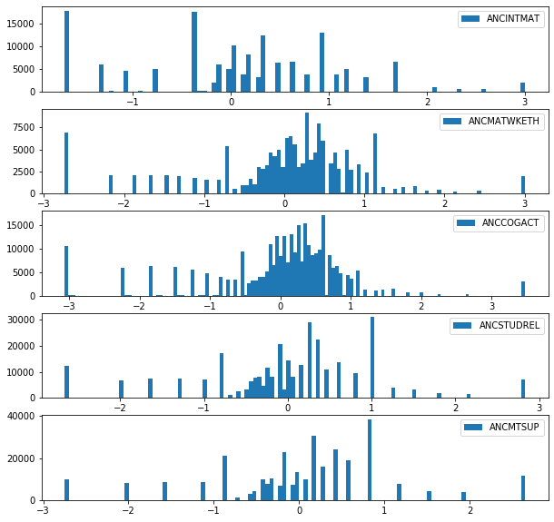

```python
# Investigate math related factors

Math_var=["ANCINTMAT","ANCMATWKETH","ANCCOGACT","ANCSTUDREL","ANCMTSUP"]
fig, ax = plt.subplots(nrows=5, figsize = [10,10])

for i in range(len(Math_var)):
    var = Math_var[i]
    ax[i].hist(data = Pisa_result, x = var, bins = np.arange(min(Pisa_result[var]), max(Pisa_result[var])+0.05, 0.05));
    ax[i].legend()
    print (var,Ab_dict[var])
```

All these math related features are discrete numerical variables. They have quite similar distribution patterns with more data points falling into the range between -1 to 1.These variables may be positively correlated with each other.We can again notice data spikes on both end of these distributions, indicating polarized math variables.

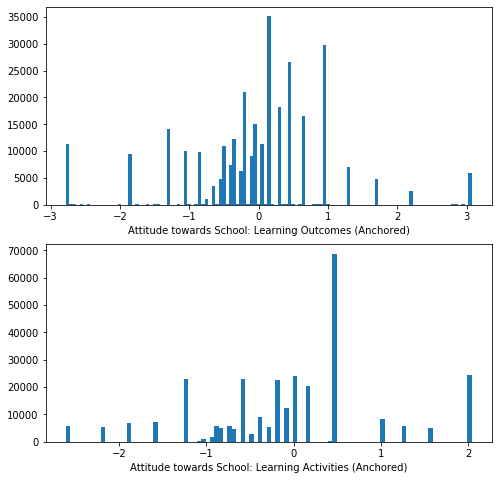

```python
# Investigate students attitute associated factors

Attitude_var=["ANCATSCHL","ANCATTLNACT"]
fig, ax = plt.subplots(nrows=2, figsize = [8,8])

for i in range(len(Attitude_var)):
    var = Attitude_var[i]
    title=Ab_dict[var]
    ax[i].hist(data = Pisa_result, x = var, bins = np.arange(min(Pisa_result[var]), max(Pisa_result[var])+0.05, 0.05));
    ax[i].set_xlabel('{}'.format(title));
```

The students attitude related features are again discrete numerical variables and have very similar distribution pattern.It's likely that these variables will be highly correlated with one another.

### Discuss the distribution(s) of your variable(s) of interest. Were there any unusual points? Did you need to perform any transformations?

Students'sense of belonging to school is discrete numerical variable. The distribution looks like an unimodal of centered around 0.2, with more data points falling into the range of -1 to 1.Notice: there are data spikes beyound both value -3 and 3, indicating that students' sense of belonging to school can be quite polarized. No unusual data points are observed in this variable.

### Of the features you investigated, were there any unusual distributions? Did you perform any operations on the data to tidy, adjust, or change the form of the data? If so, why did you do this?

When plotting the distribution for out-of-school learning time and math study time per week, most of the data is set to far left of their axes, suggesting some outliers on the right.We can also notice this on above description table. After investigating the high-outliers, I have removed those data points where students have more than 60 hours out-of-school learning time per week and more than 1500 minutes of math study time per week.

After removing the high-outliers, both study time distributions look like slightly right skewed unimodals.